# project R

Олеся Богомаз

2022-12-21

```r
library(tidyr)
library(ggplot2)
library(dplyr)
library(readr)
library(tibble)
```

```r
heart_attack<-read.csv('~/Heart_Attack_Data_Set.csv')
heart_attack[(heart_attack$sex == 1), 'sex'] <- 'Male'
heart_attack[(heart_attack$sex == 0), 'sex'] <- 'Female'
d <- heart_attack%>%count(sex)
```

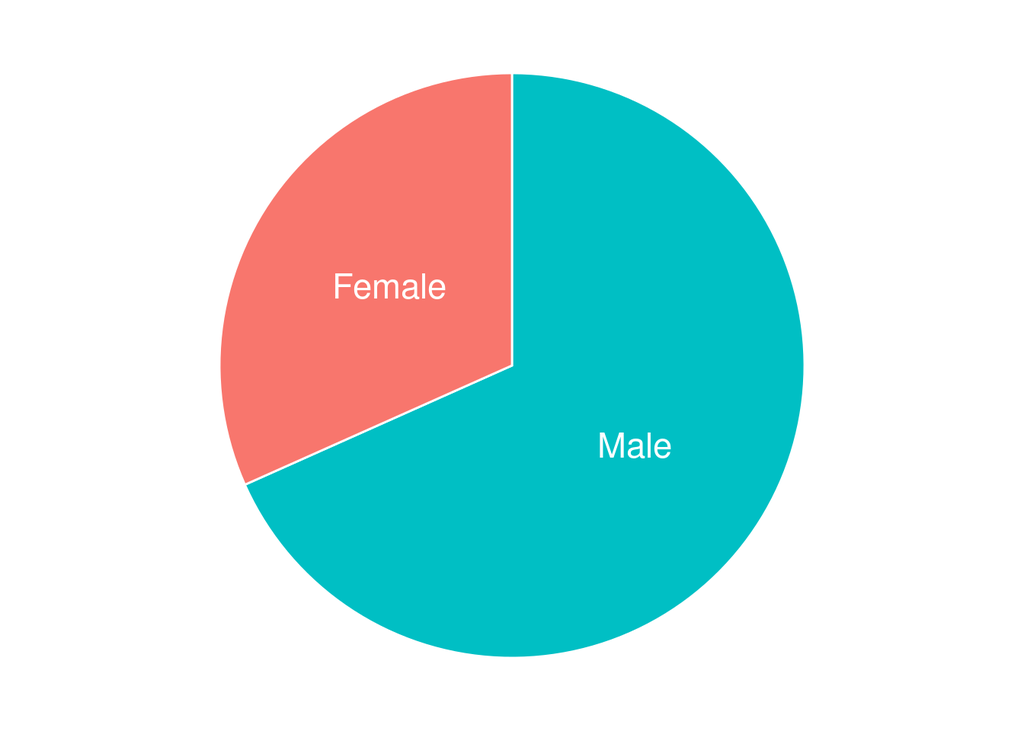

```r
data <-
  arrange(d, desc(sex)) %>%
  mutate(prop = n / sum(d$n) *100) %>%
  mutate(ypos = cumsum(prop)- 0.5*prop )



ggplot(data, aes(x="", y=prop, fill=sex)) +
  geom_bar(stat="identity", width=1, color="white") +
  coord_polar("y", start=0) +
  theme_void() +
  theme(legend.position="none") +

  geom_text(aes(y = ypos, label = sex), color = "white", size=6)
```

## Связан ли пол с инфарктами?

Чтоб определить, влияет ли пол на наличие инфаркта в нашей выборке, используем точный тест Фишера и визуализуем мозаичным графиком

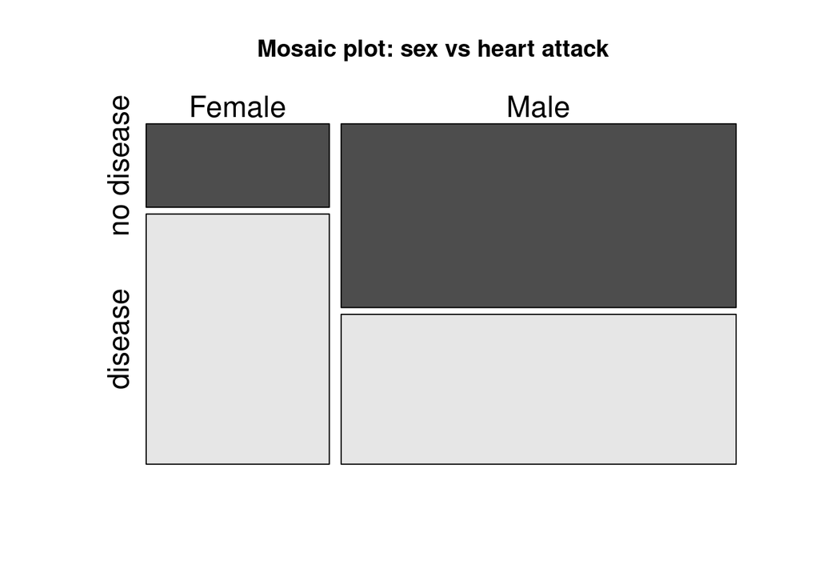

```r
fisher <- table(heart_attack$sex, heart_attack$target)
colnames(fisher) <- c('no disease', 'disease')

mosaicplot(fisher, cex.axis=1.5, main =   "Mosaic plot: sex vs heart attack",  color = TRUE)
```

```r
fisher.test(fisher)
```

```
##
##  Fisher's Exact Test for Count Data
##
## data:  fisher
## p-value = 1.042e-06
## alternative hypothesis: true odds ratio is not equal to 1
## 95 percent confidence interval:
##  0.1519598 0.4783553
## sample estimates:
## odds ratio
##  0.2731136
```

У женщин инфаркты чаще.

## Чем может быть вызвано большее число инфарктов среди женщин?

Посмотрим, какие параметры отличаются у женщин и мужчин

Все наши переменные можно поделить на колличественные (‘age’, ‘trestbps’, ‘chol’, ‘thalach’, ‘oldpeak’) и категориальные (остальные).

### Колличественные переменные

Глянем на QQ плоты и тесты Шапиро-Уилка (раздельно по полам) чтоб понять, применим ли на каких-то категориальных тест Стьюдента

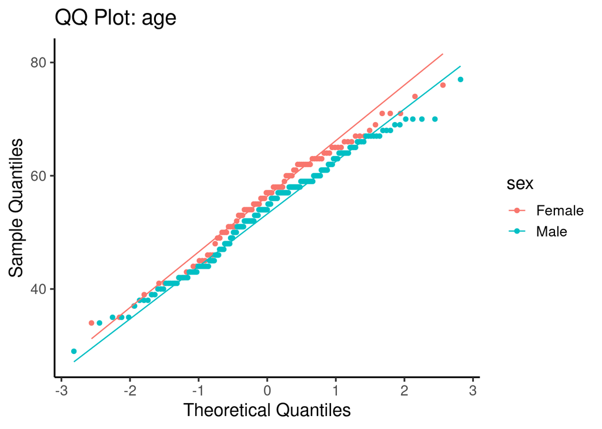

```r
ggplot(heart_attack, aes(sample = age, colour = sex))+ stat_qq() +
  stat_qq_line()+theme_classic(base_size =15)+
  labs(title = 'QQ Plot: age', x = 'Theoretical Quantiles', y = 'Sample Quantiles',  )
```

```r
shapiro.test(heart_attack[(heart_attack$sex == "Female"),'age'])
```

```
##
##  Shapiro-Wilk normality test
##
## data:  heart_attack[(heart_attack$sex == "Female"), "age"]
## W = 0.97953, p-value = 0.1386
```

```r
shapiro.test(heart_attack[(heart_attack$sex == "Male"),'age'])
```

```
##
##  Shapiro-Wilk normality test
##
## data:  heart_attack[(heart_attack$sex == "Male"), "age"]
## W = 0.9861, p-value = 0.04
```

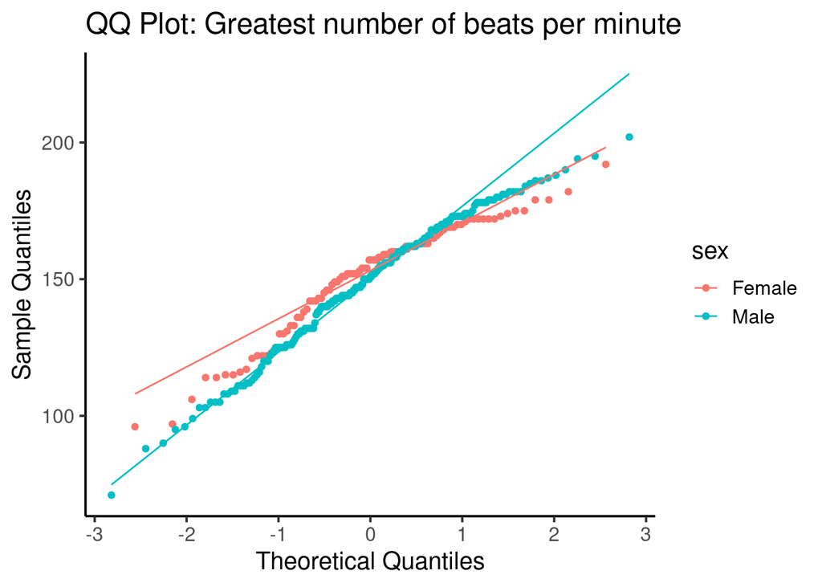

```r
ggplot(heart_attack, aes(sample = thalach, colour = sex))+ stat_qq() +
  stat_qq_line()+theme_classic(base_size =15)+
  theme_classic(base_size =15)+
  labs(title = 'QQ Plot: Greatest number of beats per minute', x = 'Theoretical Quantiles', y = 'Sample Quantiles' )
```

```r
shapiro.test(heart_attack[(heart_attack$sex == "Female"),'thalach'])
```

```
##
##  Shapiro-Wilk normality test
##
## data:  heart_attack[(heart_attack$sex == "Female"), "thalach"]
## W = 0.94423, p-value = 0.0004753
```

```r
shapiro.test(heart_attack[(heart_attack$sex == "Male"),'thalach'])
```

```
##
##  Shapiro-Wilk normality test
##
## data:  heart_attack[(heart_attack$sex == "Male"), "thalach"]
## W = 0.98175, p-value = 0.00871
```

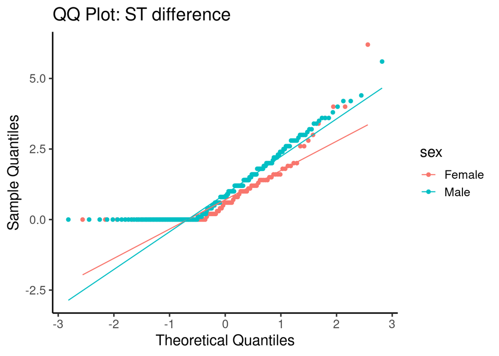

```r
ggplot(heart_attack, aes(sample = oldpeak, colour = sex))+ stat_qq() +
  stat_qq_line()+
  theme_classic(base_size =15)+
  labs(title = 'QQ Plot: ST difference', x = 'Theoretical Quantiles', y = 'Sample Quantiles' )
```

```r
shapiro.test(heart_attack[(heart_attack$sex == "Female"),'oldpeak'])
```

```
##
##  Shapiro-Wilk normality test
##
## data:  heart_attack[(heart_attack$sex == "Female"), "oldpeak"]
## W = 0.77444, p-value = 7.893e-11
```

```r
shapiro.test(heart_attack[(heart_attack$sex == "Male"),'oldpeak'])
```

```
##
##  Shapiro-Wilk normality test
##
## data:  heart_attack[(heart_attack$sex == "Male"), "oldpeak"]
## W = 0.86764, p-value = 1.902e-12
```

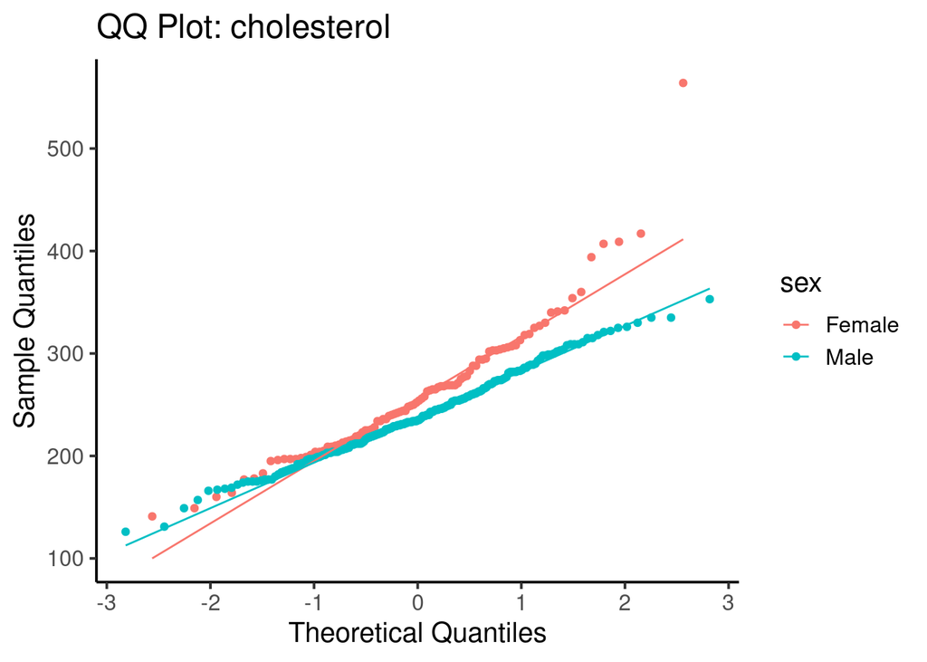

```r
ggplot(heart_attack, aes(sample = chol, colour = sex))+ stat_qq() +
  stat_qq_line()+
  theme_classic(base_size =15)+
  labs(title = 'QQ Plot: cholesterol', x = 'Theoretical Quantiles', y = 'Sample Quantiles' )
```

```r
shapiro.test(heart_attack[(heart_attack$sex == "Female"),'chol'])
```

```
##
##  Shapiro-Wilk normality test
##
## data:  heart_attack[(heart_attack$sex == "Female"), "chol"]
## W = 0.92325, p-value = 3.017e-05
```

```r
shapiro.test(heart_attack[(heart_attack$sex == "Male"),'chol'])
```

```
##
##  Shapiro-Wilk normality test
##
## data:  heart_attack[(heart_attack$sex == "Male"), "chol"]
## W = 0.99369, p-value = 0.5273
```

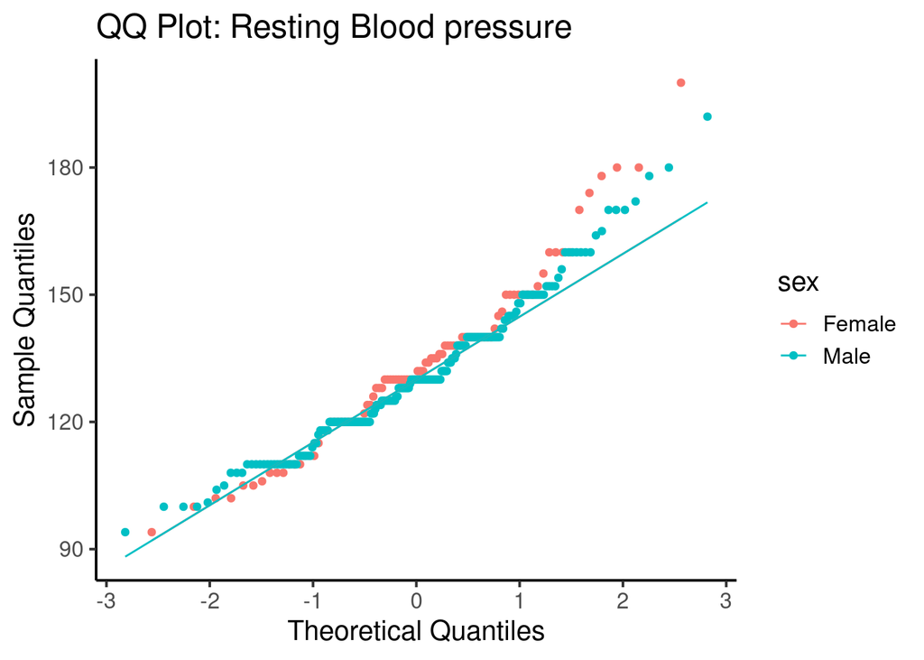

```r
ggplot(heart_attack, aes(sample = trestbps, colour = sex))+ stat_qq() +
  stat_qq_line()+theme_classic(base_size =15)+
  labs(title = 'QQ Plot: Resting Blood pressure', x = 'Theoretical Quantiles', y = 'Sample Quantiles' )
```

```r
shapiro.test(heart_attack[(heart_attack$sex == "Female"),'trestbps'])
```

```
##
##  Shapiro-Wilk normality test
##
## data:  heart_attack[(heart_attack$sex == "Female"), "trestbps"]
## W = 0.96133, p-value = 0.006315
```

```r
shapiro.test(heart_attack[(heart_attack$sex == "Male"),'trestbps'])
```

```
##
##  Shapiro-Wilk normality test
##
## data:  heart_attack[(heart_attack$sex == "Male"), "trestbps"]
## W = 0.96757, p-value = 0.0001065
```

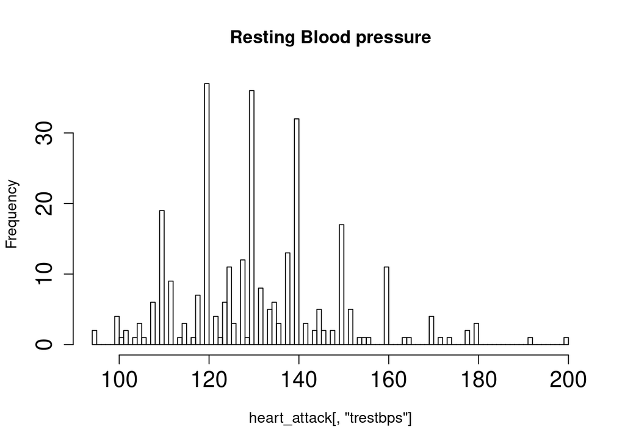

```r
hist(heart_attack[,'trestbps'], breaks=100, cex.axis=1.5,   cex.axis=1.5,   main =   'Resting Blood pressure' )
```

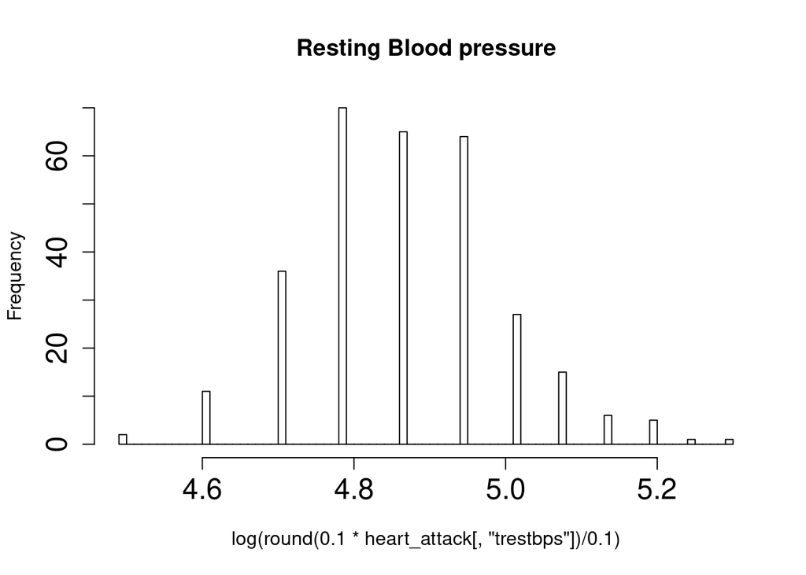

```r
hist(log(round(0.1*heart_attack[,'trestbps'])/0.1), breaks=100, cex.axis=1.5,   main =  'Resting Blood pressure')
```

Дальше округлим с точностью до 10 мм.рт.ст.

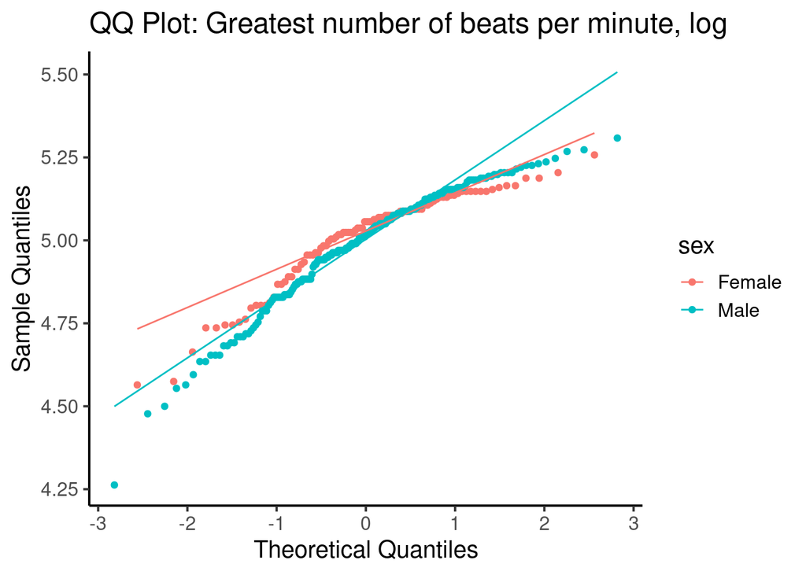

```r
ggplot(heart_attack, aes(sample = log(thalach), colour = sex))+ stat_qq() +
  stat_qq_line()+theme_classic(base_size =15)+
  theme_classic(base_size =15)+
  labs(title = 'QQ Plot: Greatest number of beats per minute, log', x = 'Theoretical Quantiles', y = 'Sample Quantiles' )
```

```r
shapiro.test(log(heart_attack[(heart_attack$sex == "Female"),'thalach']))
```

```
##
##  Shapiro-Wilk normality test
##
## data:  log(heart_attack[(heart_attack$sex == "Female"), "thalach"])
## W = 0.90947, p-value = 6.014e-06
```

```r
shapiro.test(log(heart_attack[(heart_attack$sex == "Male"),'thalach']))
```

```
##
##  Shapiro-Wilk normality test
##
## data:  log(heart_attack[(heart_attack$sex == "Male"), "thalach"])
## W = 0.9471, p-value = 6.806e-07
```

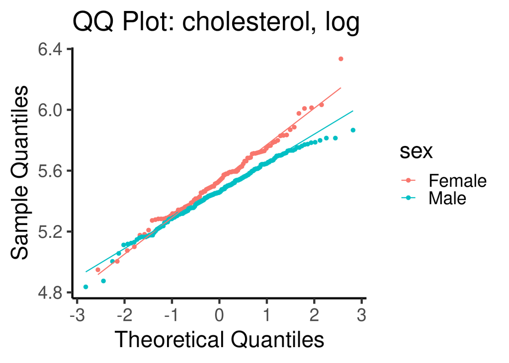

```r
ggplot(heart_attack, aes(sample = log(chol), colour = sex))+ stat_qq() +
  stat_qq_line()+
  theme_classic(base_size =22)+
  labs(title = 'QQ Plot: cholesterol, log', x = 'Theoretical Quantiles', y = 'Sample Quantiles' )
```

```r
shapiro.test(log(heart_attack[(heart_attack$sex == "Female"),'chol']))
```

```
##
##  Shapiro-Wilk normality test
##
## data:  log(heart_attack[(heart_attack$sex == "Female"), "chol"])
## W = 0.9883, p-value = 0.5607
```

```r
shapiro.test(log(heart_attack[(heart_attack$sex == "Male"),'chol']))
```

```
##
##  Shapiro-Wilk normality test
##
## data:  log(heart_attack[(heart_attack$sex == "Male"), "chol"])
## W = 0.98872, p-value = 0.1023
```

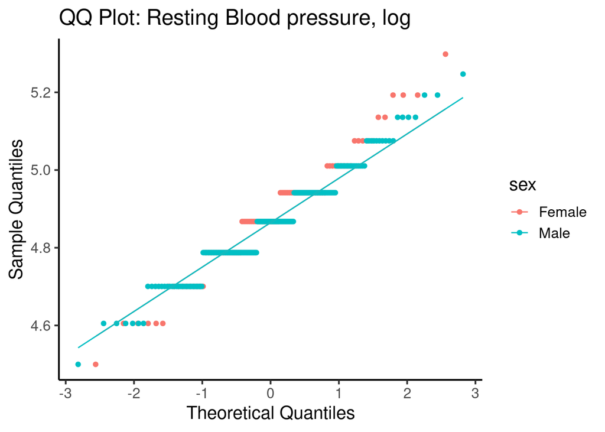

```r
ggplot(heart_attack, aes(sample = log(round(0.1*trestbps)/0.1), colour =sex))+ stat_qq() +
  stat_qq_line()+theme_classic(base_size =15)+
  labs(title = 'QQ Plot: Resting Blood pressure, log', x = 'Theoretical Quantiles', y = 'Sample Quantiles' )
```

```r
shapiro.test(log(round(0.1*heart_attack[(heart_attack$sex == "Female"),'trestbps'])/0.1))
```

```
##
##  Shapiro-Wilk normality test
##
## data:  log(round(0.1 * heart_attack[(heart_attack$sex == "Female"),     "trestbps"])/0.1)
## W = 0.96993, p-value = 0.02632
```

```r
shapiro.test(log(round(0.1*heart_attack[(heart_attack$sex == "Male"),'trestbps'])/0.1))
```

```
##
##  Shapiro-Wilk normality test
##
## data:  log(round(0.1 * heart_attack[(heart_attack$sex == "Male"), "trestbps"])/0.1)
## W = 0.96292, p-value = 3.019e-05
```

Данные по холестерину в крови оказались распределены лог-нормально

Применим тест Стьюдента на нормально распределенных величинах и тест Манна-Уитни на ненормально.

```r
t.test(heart_attack[(heart_attack$sex == "Female"),'age'],
            heart_attack[(heart_attack$sex == "Male"),'age'], alternative = 'greater')
```

```
##
##  Welch Two Sample t-test
##
## data:  heart_attack[(heart_attack$sex == "Female"), "age"] and heart_attack[(heart_attack$sex == "Male"), "age"]
## t = 1.6805, df = 175.92, p-value = 0.04732
## alternative hypothesis: true difference in means is greater than 0
## 95 percent confidence interval:
##  0.03072601        Inf
## sample estimates:
## mean of x mean of y
##  55.67708  53.75845
```

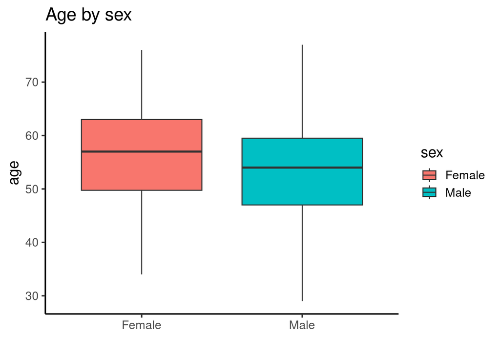

```r
ggplot(heart_attack, aes(sex, age)) + geom_boxplot(aes(fill=sex))+ theme_classic(base_size =15)+labs (title='Age by sex', x='')
```

```r
wilcox.test(heart_attack[(heart_attack$sex == "Female"),'thalach'],
            heart_attack[(heart_attack$sex == "Male"),'thalach'], , alternative = 'greater')
```

```
##
##  Wilcoxon rank sum test with continuity correction
##
## data:  heart_attack[(heart_attack$sex == "Female"), "thalach"] and heart_attack[(heart_attack$sex == "Male"), "thalach"]
## W = 10428, p-value = 0.2444
## alternative hypothesis: true location shift is greater than 0
```

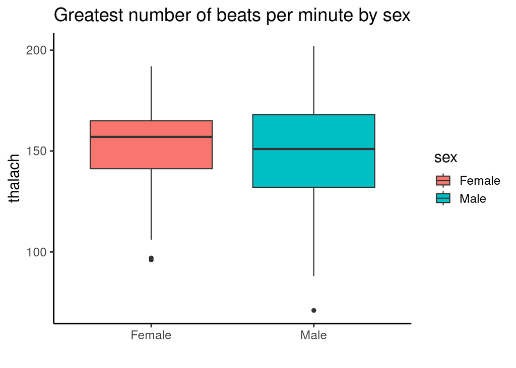

```r
ggplot(heart_attack, aes(sex, thalach)) + geom_boxplot(aes(fill=sex))+ theme_classic(base_size =15)+labs (title='Greatest number of beats per minute by sex', x='')
```

```r
wilcox.test(heart_attack[(heart_attack$sex == "Female"),'oldpeak'],
            heart_attack[(heart_attack$sex == "Male"),'oldpeak'], , alternative = 'greater')
```

```
##
##  Wilcoxon rank sum test with continuity correction
##
## data:  heart_attack[(heart_attack$sex == "Female"), "oldpeak"] and heart_attack[(heart_attack$sex == "Male"), "oldpeak"]
## W = 8716.5, p-value = 0.96
## alternative hypothesis: true location shift is greater than 0
```

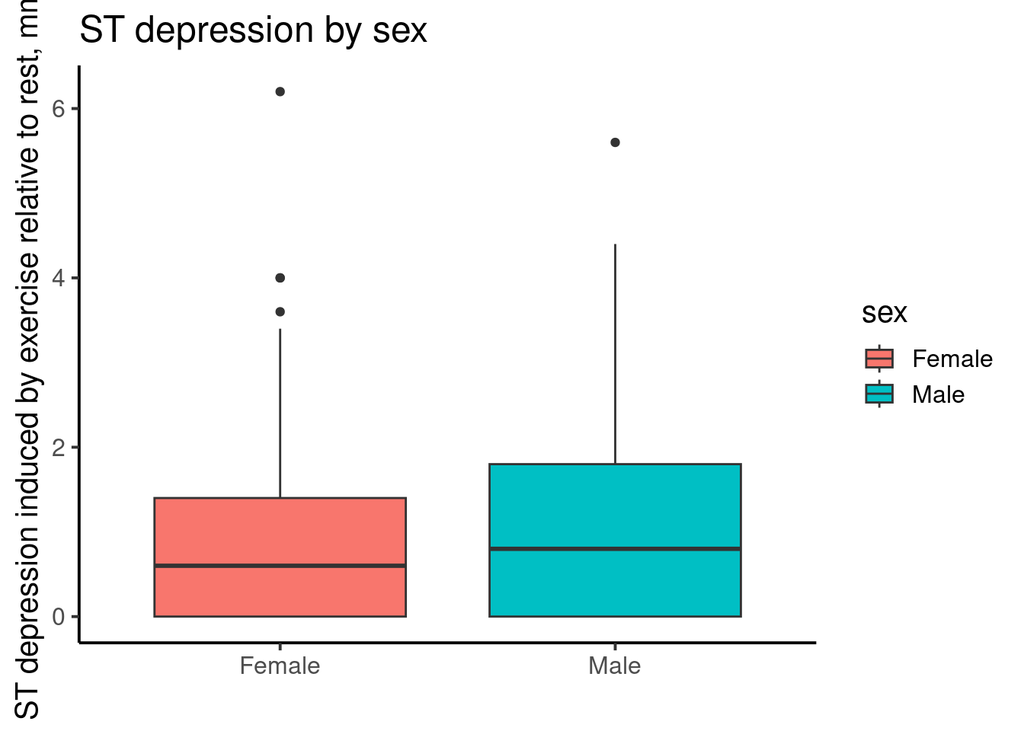

```r
ggplot(heart_attack, aes(sex, oldpeak)) + geom_boxplot(aes(fill=sex))+ theme_classic(base_size =15)+labs (title='ST depression by sex', x='', y='ST depression induced by exercise relative to rest, mm')
```

```r
t.test(log(heart_attack[(heart_attack$sex == "Female"),'chol']),
            log(heart_attack[(heart_attack$sex == "Male"),'chol']), , alternative = 'greater')
```

```
##
##  Welch Two Sample t-test
##
## data:  log(heart_attack[(heart_attack$sex == "Female"), "chol"]) and log(heart_attack[(heart_attack$sex == "Male"), "chol"])
## t = 2.8095, df = 150.51, p-value = 0.002811
## alternative hypothesis: true difference in means is greater than 0
## 95 percent confidence interval:
##  0.03135843        Inf
## sample estimates:
## mean of x mean of y
##  5.537650  5.461334
```

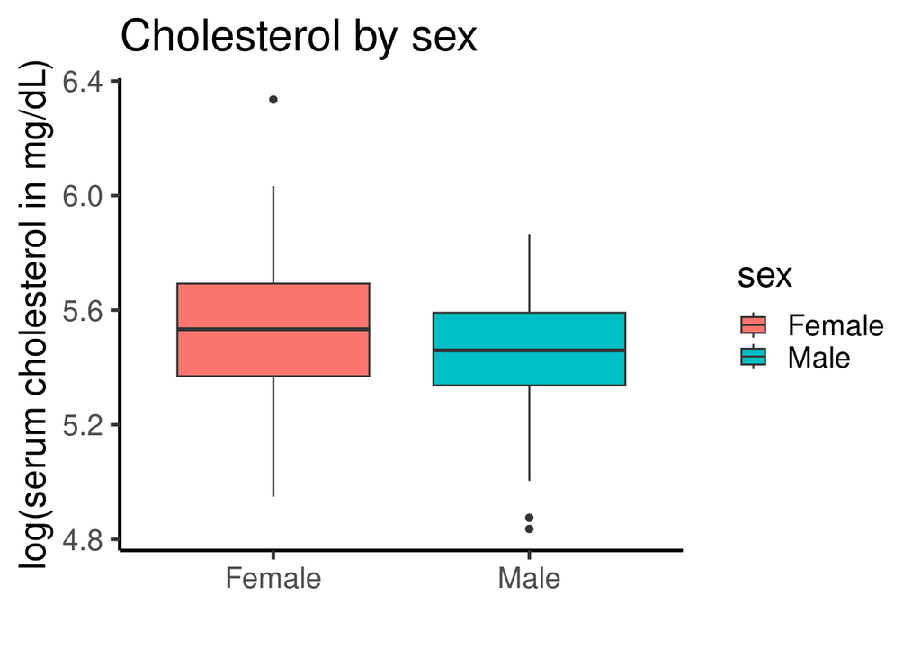

```r
ggplot(heart_attack, aes(sex, log(chol))) + geom_boxplot(aes(fill=sex))+ theme_classic(base_size =20)+labs (title='Cholesterol by sex', x='', y='log(serum cholesterol in mg/dL)')
```

```r
wilcox.test(round(0.1*heart_attack[(heart_attack$sex == "Female"),'trestbps'])/0.1,
            round(0.1*heart_attack[(heart_attack$sex == "Male"),'trestbps'])/0.1)
```

```
##
##  Wilcoxon rank sum test with continuity correction
##
## data:  round(0.1 * heart_attack[(heart_attack$sex == "Female"), "trestbps"])/0.1 and round(0.1 * heart_attack[(heart_attack$sex == "Male"), "trestbps"])/0.1
## W = 10784, p-value = 0.2242
## alternative hypothesis: true location shift is not equal to 0
```

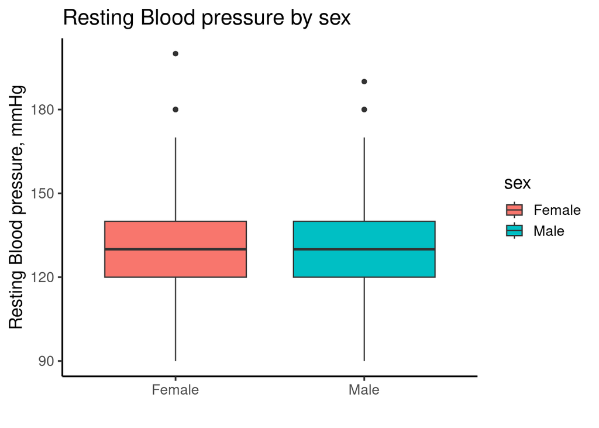

```r
ggplot(heart_attack, aes(sex, round(0.1*trestbps)/0.1)) + geom_boxplot(aes(fill=sex))+ theme_classic(base_size =15)+labs (title='Resting Blood pressure by sex', x='', y='Resting Blood pressure, mmHg')
```

### Категориальные переменные

Вспомним, что есть и категориальные признаки: боль в груди (4 варианта), повышен ли сахар в крови, данные ЭКГ, стенокрдия при нагрузке, наклон ST-пика на кардиограмме, количество крупных сосудов сердца, заполняемых кровью. Для признаков с двумя вариантами или нулевыми ячейками использую точный тест Фишера, в остальных случаях - критерий Пирсона.

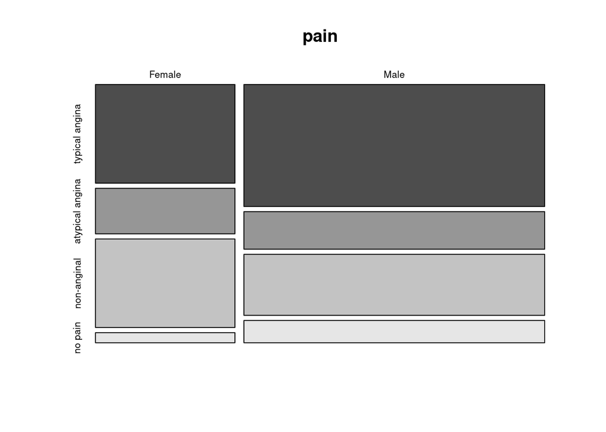

```r
pain <- table(heart_attack$sex, heart_attack$cp)
colnames(pain)<-c('typical angina' ,'atypical angina','non-anginal', 'no pain')
mosaicplot(pain, color =TRUE)
```

```r
chisq.test(pain)
```

```
##
##  Pearson's Chi-squared test
##
## data:  pain
## X-squared = 6.8221, df = 3, p-value = 0.07779
```

```r
blood_glucose <- table(heart_attack$sex, heart_attack$fbs)
colnames(blood_glucose )<- c('normal', 'high')
blood_glucose
```

```
##
##          normal high
##   Female     84   12
##   Male      174   33
```

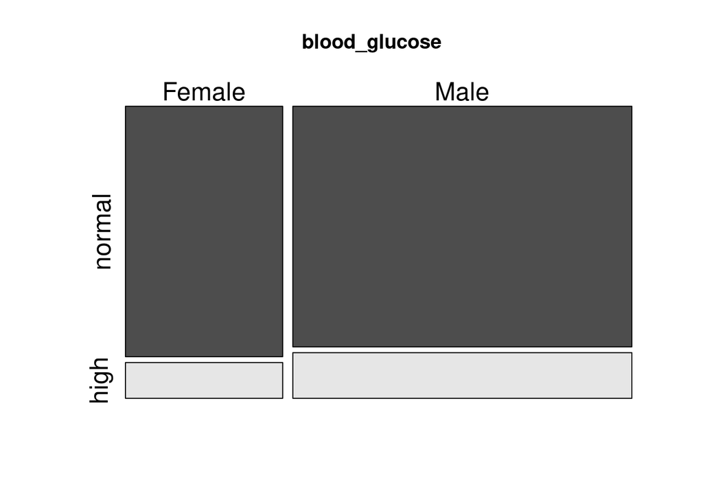

```r
mosaicplot(blood_glucose, color =TRUE, cex.axis=1.5)
```

```r
fisher.test(blood_glucose)
```

```
##
##  Fisher's Exact Test for Count Data
##
## data:  blood_glucose
## p-value = 0.4907
## alternative hypothesis: true odds ratio is not equal to 1
## 95 percent confidence interval:
##  0.6286669 2.9698015
## sample estimates:
## odds ratio
##   1.326388
```

```r
Rest_ECG <- table(heart_attack$sex, heart_attack$restecg)

colnames( Rest_ECG)<- c('normal', 'abnormal ST', 'hypertrophy of LV')
Rest_ECG
```

```
##
##          normal abnormal ST hypertrophy of LV
##   Female     44          49                 3
##   Male      103         103                 1
```

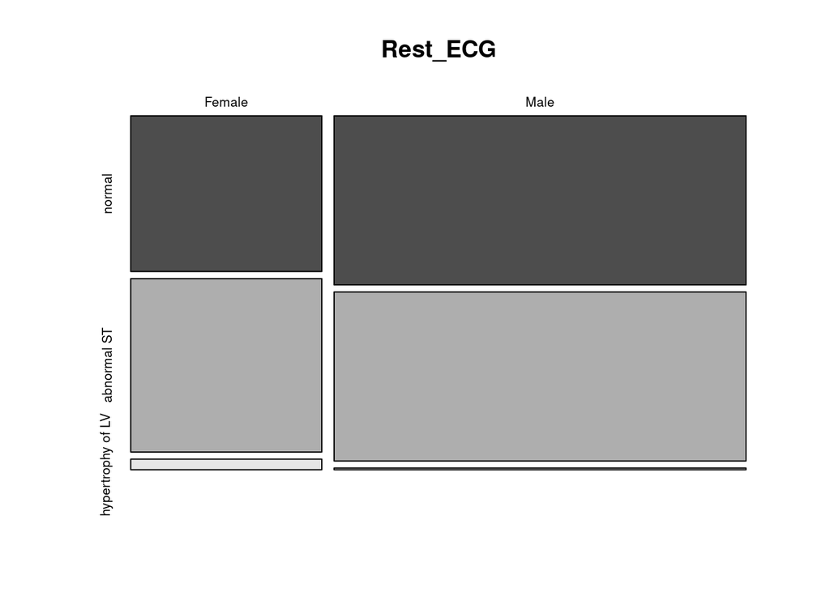

```r
mosaicplot(Rest_ECG,  color =TRUE)
```

```r
fisher.test(Rest_ECG)
```

```
##
##  Fisher's Exact Test for Count Data
##
## data:  Rest_ECG
## p-value = 0.1633
## alternative hypothesis: two.sided
```

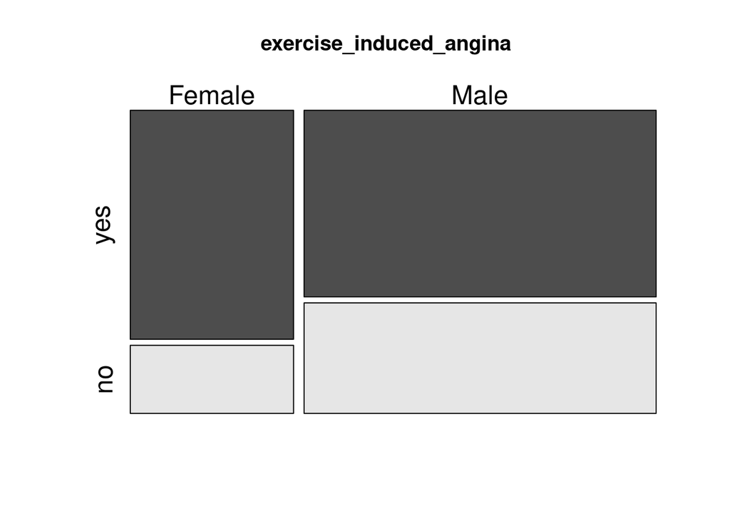

```r
exercise_induced_angina <- table(heart_attack$sex, heart_attack$exang)

colnames(exercise_induced_angina)<- c('yes', 'no')
mosaicplot(exercise_induced_angina, color =TRUE,  cex.axis=1.5)
```

```r
fisher.test(exercise_induced_angina)
```

```
##
##  Fisher's Exact Test for Count Data
##
## data:  exercise_induced_angina
## p-value = 0.0175
## alternative hypothesis: true odds ratio is not equal to 1
## 95 percent confidence interval:
##  1.114959 3.643275
## sample estimates:
## odds ratio
##   1.987969
```

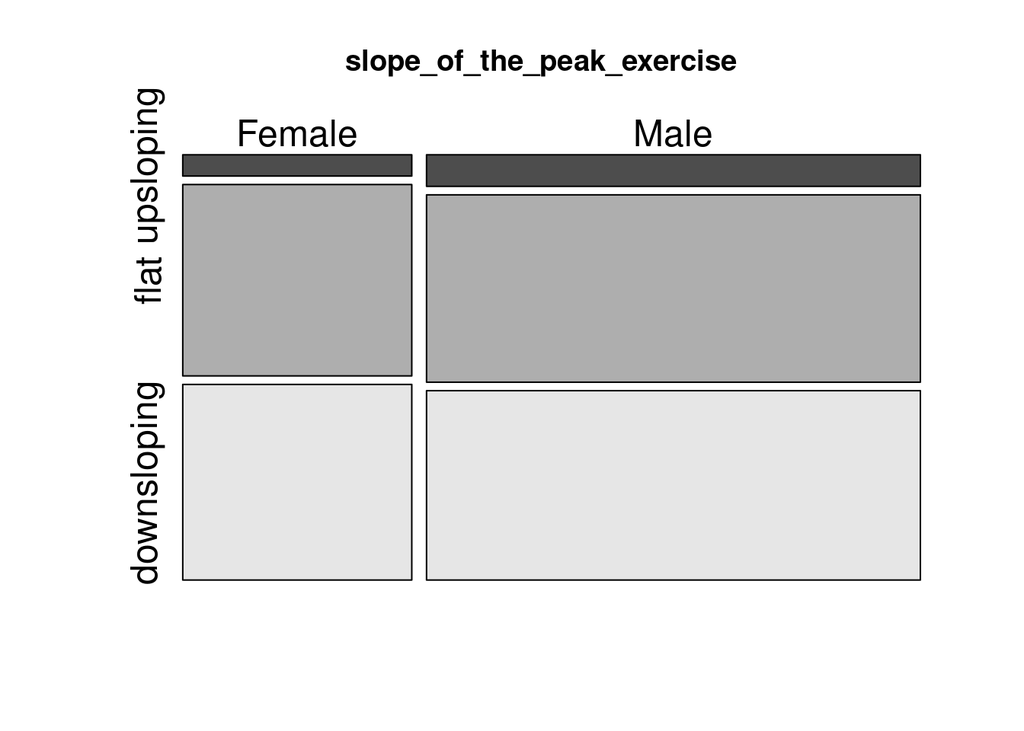

```r
slope_of_the_peak_exercise <- table(heart_attack$sex, heart_attack$slope)
colnames(slope_of_the_peak_exercise) <- c('upsloping', 'flat', 'downsloping')
mosaicplot(slope_of_the_peak_exercise, color =TRUE,cex.axis=1.5 )
```

```r
chisq.test(slope_of_the_peak_exercise)
```

```
##
##  Pearson's Chi-squared test
##
## data:  slope_of_the_peak_exercise
## X-squared = 0.64832, df = 2, p-value = 0.7231
```

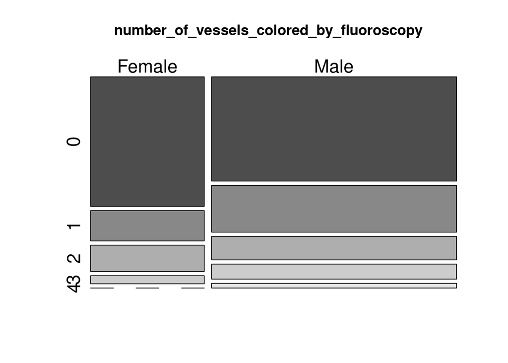

```r
number_of_vessels_colored_by_fluoroscopy <- table(heart_attack$sex, heart_attack$ca)

mosaicplot(number_of_vessels_colored_by_fluoroscopy, cex.axis=1.5,  color =TRUE)
```

```r
fisher.test(number_of_vessels_colored_by_fluoroscopy)
```

```
##
##  Fisher's Exact Test for Count Data
##
## data:  number_of_vessels_colored_by_fluoroscopy
## p-value = 0.1091
## alternative hypothesis: two.sided
```

На уровне значимости 0.05 есть разница только по стенокардии при нагрузке

## Поправка на множественное тестирование

Я провела довольно много тестов, пора это учесть. Применим поправку Бенжамини-Хохберга

```r
p.adjust(c(0.04732, 0.2444,0.96,0.002811,0.2242,0.07779,0.4907,0.1633,0.0175,1.987969 ,0.7231,0.1091), method = 'BH')
```

```
##  [1] 0.1892800 0.3666000 1.0000000 0.0337320 0.3666000 0.2333700 0.6542667
##  [8] 0.3266000 0.1050000 1.0000000 0.8677200 0.2618400
```

На уровне значимости 5% осталось только различие по холестерину.

## Выводы

1. Женщины чаще, чем мужчины, страдают инфарктом.
2. Значимое различие по полам наблюдается только в количестве холестерина в крови.